# Final Project

Anna Repesh & Bella Mahmoud

10/13/2021

```r
knitr::opts_chunk$set(error = TRUE)
library(tidyverse)
```

## Project Proposal

Are people getting pregnant later in life?

A common headline seen today is that millennials are choosing to have children later in life. Years ago, it was common for people to have children in their 20s, but nowadays, it is being seen that as people further their education and participate in the workforce, having children becomes less of a focus (Phan 2013).

Our project will look at pregnancy rates by states between the years of 2000-2017 for age groups 20-24, 25-29, 30-34, and 35-39. Our goal is to evaluate if people are getting pregnant later in life than in the early 2000s. Our findings will hopefully support the statement that people are opting to have children later in life.

We will create a website with graphics for our project. Specifically, we aim to have line graph(s) that will depict the trend of pregnancy rates by state over a 17 year period and bar graphs that will show the difference in pregnancy rates for the years 2000 and 2017 for the age groups 20-24, 25-29, 30-34, and 35-39.

We will create a website with graphics for our project. Specifically, we aim to have line graph(s) that will depict the trend of pregnancy rates over a 17 year period and bar graphs that will show the difference in pregnancy rates for the years 2000 and 2017 for the age groups 20-24, 25-29, 30-34, and 35-39.

Phan, L. (2013). Women’s empowerment and fertility changes. International Journal of Sociology of the Family, 39(1/2), 49–75.

## Original Data

```r
Birth <- read_csv("NationalAndStatePregnancy_PublicUse.csv")
```

## Filtered Data for Project

```r
Birth2 <- Birth %>%
  select("state", "year", "pregnancyrate2024" : "pregnancyrate3539") %>%
  filter(year >= 2000, state != "US" & state != "DC")



Birth2 %>%
 DT::datatable()
```

|  | state | year | pregnancyrate2024 | pregnancyrate2529 | pregnancyrate3034 | pregnancyrate3539 |
| --- | --- | --- | --- | --- | --- | --- |
| 1 | AL | 2000 | 186.8 | 158.7 | 96.1 | 37.6 |
| 2 | AL | 2005 | 165.8 | 154.8 | 100.5 | 40.7 |
| 3 | AL | 2006 | 171.6 | 159.1 | 100.8 | 42.1 |
| 4 | AL | 2007 | 175.1 | 160.7 | 104.5 | 43.2 |
| 5 | AL | 2008 | 171.4 | 160.6 | 104.5 | 42.1 |
| 6 | AL | 2009 | 160.6 | 155.3 | 103.8 | 40.4 |
| 7 | AL | 2010 | 148.8 | 152.4 | 101.8 | 40.2 |
| 8 | AL | 2011 | 142.8 | 150.2 | 102.8 | 41.6 |
| 9 | AL | 2012 | 134.7 | 148 | 104.1 | 41.7 |
| 10 | AL | 2013 | 134.7 | 147.6 | 103.6 | 41.8 |

[output cut: 690 more lines]

```r
Pivot_Birth <- Birth2 %>%
  pivot_longer(!state:year, names_to = "Group", values_to = "Rate")
```

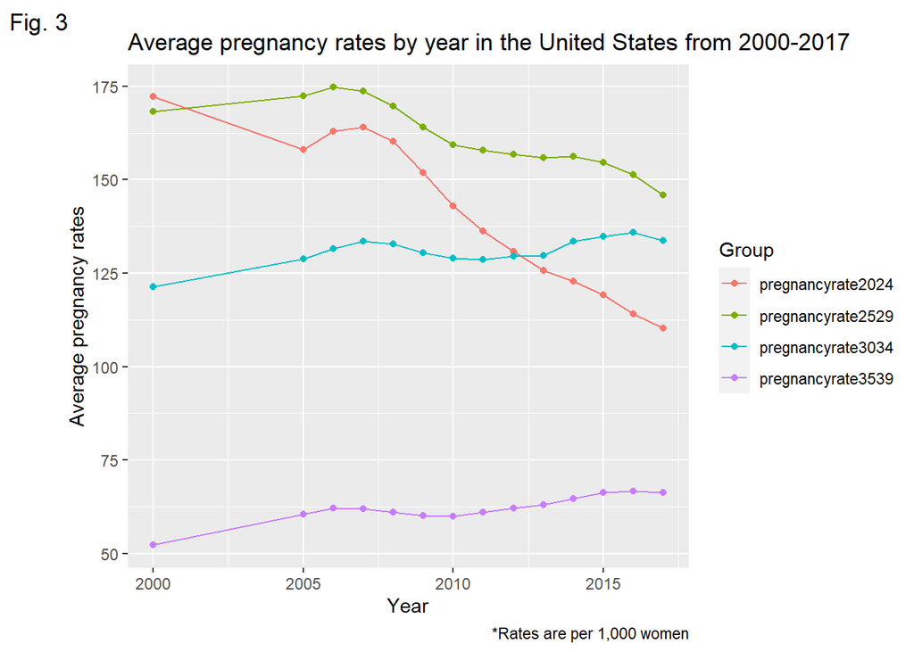

```r
Pivot_Birth %>%
  group_by(Group, year) %>%
  summarise(Rate_avg = mean(Rate)) %>%
  ggplot(aes(x = year, y = Rate_avg, color= Group)) +
  geom_point() +
  geom_line() +
  labs(x = "Year",
       y= "Average pregnancy rates",
       title = "Average pregnancy rates by year in the United States from 2000-2017",
       caption = "*Rates are per 1,000 women",
       tag = "Fig. 3")
```

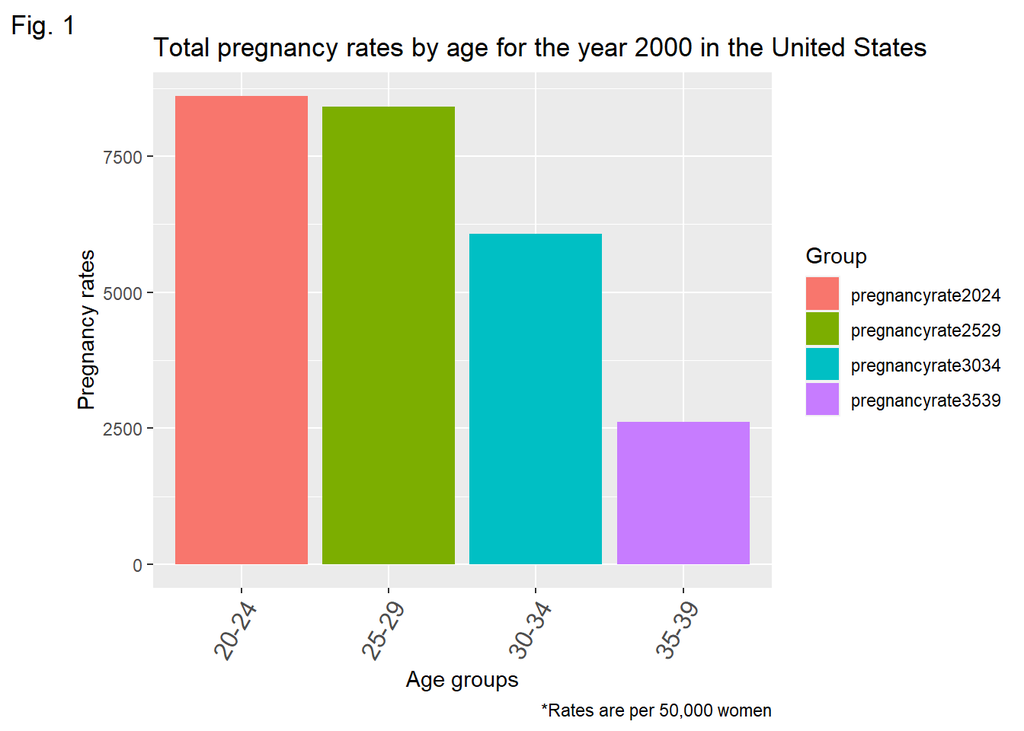

```r
Pivot_Birth %>%
  filter(year == 2000) %>%
  ggplot(aes(x= Group, y= Rate, fill = Group)) +
  geom_col() +
  scale_x_discrete(labels=c("20-24", "25-29", "30-34", "35-39")) +
  labs(x = "Age groups",
       y= "Pregnancy rates",
       title = "Total pregnancy rates by age for the year 2000 in the United States",
       caption = "*Rates are per 50,000 women",
       tag = "Fig. 1")  +
  theme(axis.text.x = element_text(angle = 60, size=12, hjust = 1))
```

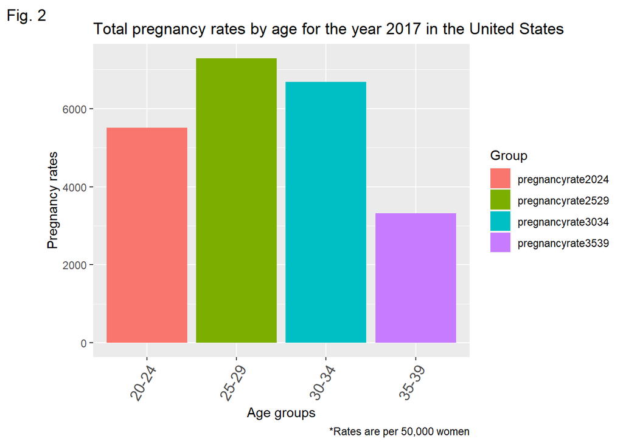

```r
Pivot_Birth %>%
  filter(year == 2017) %>%
  ggplot(aes(x= Group, y= Rate, fill = Group)) +
  geom_col() +
  scale_x_discrete(labels=c("20-24", "25-29", "30-34", "35-39")) +
  labs(x = "Age groups",
       y= "Pregnancy rates",
       title = "Total pregnancy rates by age for the year 2017 in the United States",
       caption = "*Rates are per 50,000 women",
       tag = "Fig. 2")  +
  theme(axis.text.x = element_text(angle = 60, size=12, hjust = 1))
```